# Risk Factor Analysis

## Outcome Variable

**Outcome Variable:** co_occurence

## Predictor Variables

**Intervention Variable:** pers_wasted06

**Adjustment Set:**

unadjusted

## Stratifying Variables

The analysis was stratified on these variable(s):

- studyid
- country

## Data Summary

| studyid | country | pers_wasted06 | co_occurence | n_cell | n |
| --- | --- | --- | --- | --- | --- |
| CMC-V-BCS-2002 | INDIA | 0 | 0 | 308 | 366 |
| CMC-V-BCS-2002 | INDIA | 0 | 1 | 7 | 366 |
| CMC-V-BCS-2002 | INDIA | 1 | 0 | 36 | 366 |
| CMC-V-BCS-2002 | INDIA | 1 | 1 | 15 | 366 |
| CMIN | BANGLADESH | 0 | 0 | 205 | 237 |
| CMIN | BANGLADESH | 0 | 1 | 23 | 237 |
| CMIN | BANGLADESH | 1 | 0 | 6 | 237 |
| CMIN | BANGLADESH | 1 | 1 | 3 | 237 |
| COHORTS | GUATEMALA | 0 | 0 | 706 | 774 |
| COHORTS | GUATEMALA | 0 | 1 | 31 | 774 |
| COHORTS | GUATEMALA | 1 | 0 | 30 | 774 |
| COHORTS | GUATEMALA | 1 | 1 | 7 | 774 |
| COHORTS | PHILIPPINES | 0 | 0 | 2191 | 2487 |
| COHORTS | PHILIPPINES | 0 | 1 | 154 | 2487 |
| COHORTS | PHILIPPINES | 1 | 0 | 109 | 2487 |
| COHORTS | PHILIPPINES | 1 | 1 | 33 | 2487 |
| CONTENT | PERU | 0 | 0 | 200 | 200 |
| CONTENT | PERU | 0 | 1 | 0 | 200 |
| CONTENT | PERU | 1 | 0 | 0 | 200 |
| CONTENT | PERU | 1 | 1 | 0 | 200 |
| EE | PAKISTAN | 0 | 0 | 258 | 346 |
| EE | PAKISTAN | 0 | 1 | 63 | 346 |
| EE | PAKISTAN | 1 | 0 | 14 | 346 |
| EE | PAKISTAN | 1 | 1 | 11 | 346 |
| GMS-Nepal | NEPAL | 0 | 0 | 440 | 550 |
| GMS-Nepal | NEPAL | 0 | 1 | 47 | 550 |
| GMS-Nepal | NEPAL | 1 | 0 | 50 | 550 |
| GMS-Nepal | NEPAL | 1 | 1 | 13 | 550 |
| IRC | INDIA | 0 | 0 | 325 | 405 |
| IRC | INDIA | 0 | 1 | 22 | 405 |

[output cut: 78 more lines]

The following strata were considered:

- studyid: CMC-V-BCS-2002, country: INDIA
- studyid: CMIN, country: BANGLADESH
- studyid: COHORTS, country: GUATEMALA
- studyid: COHORTS, country: PHILIPPINES
- studyid: CONTENT, country: PERU
- studyid: EE, country: PAKISTAN
- studyid: GMS-Nepal, country: NEPAL
- studyid: IRC, country: INDIA
- studyid: JiVitA-4, country: BANGLADESH
- studyid: Keneba, country: GAMBIA
- studyid: LCNI-5, country: MALAWI
- studyid: MAL-ED, country: BANGLADESH
- studyid: MAL-ED, country: BRAZIL
- studyid: MAL-ED, country: INDIA
- studyid: MAL-ED, country: NEPAL
- studyid: MAL-ED, country: PERU
- studyid: MAL-ED, country: SOUTH AFRICA
- studyid: MAL-ED, country: TANZANIA, UNITED REPUBLIC OF
- studyid: NIH-Birth, country: BANGLADESH
- studyid: NIH-Crypto, country: BANGLADESH
- studyid: PROBIT, country: BELARUS
- studyid: PROVIDE, country: BANGLADESH
- studyid: ResPak, country: PAKISTAN
- studyid: SAS-CompFeed, country: INDIA
- studyid: SAS-FoodSuppl, country: INDIA
- studyid: TanzaniaChild2, country: TANZANIA, UNITED REPUBLIC OF
- studyid: ZVITAMBO, country: ZIMBABWE

### Dropped Strata

Some strata were dropped due to rare outcomes:

- studyid: CMIN, country: BANGLADESH
- studyid: CONTENT, country: PERU
- studyid: IRC, country: INDIA
- studyid: LCNI-5, country: MALAWI
- studyid: MAL-ED, country: BANGLADESH
- studyid: MAL-ED, country: BRAZIL
- studyid: MAL-ED, country: INDIA
- studyid: MAL-ED, country: NEPAL
- studyid: MAL-ED, country: PERU
- studyid: MAL-ED, country: SOUTH AFRICA
- studyid: MAL-ED, country: TANZANIA, UNITED REPUBLIC OF
- studyid: PROBIT, country: BELARUS
- studyid: PROVIDE, country: BANGLADESH
- studyid: ResPak, country: PAKISTAN
- studyid: TanzaniaChild2, country: TANZANIA, UNITED REPUBLIC OF

## Methods Detail

We’re interested in the causal parameters $E[Y_a]$ for all values of $a \in \mathcal{A}$. These parameters represent the mean outcome if, possibly contrary to fact, we intervened to set all units to have $A=a$. Under the randomization and positivity assumptions, these are identified by the statistical parameters $\psi_a=E_W[E_{Y|A,W}(Y|A=a,W)]$. In addition, we’re interested in the mean of $Y$, $E[Y]$ under no intervention (the observed mean). We will estimate these parameters by using SuperLearner to fit the relevant likelihood factors – $E_{Y|A,W}(Y|A=a,W)$ and $p(A=a|W)$, and then updating our likelihood fit using a joint TMLE.

For unadjusted analyses ($W=\{\}$), initial likelihoods were estimated using Lrnr_glm to estimate the simple $E(Y|A)$ and Lrnr_mean to estimate $p(A)$. For adjusted analyses, a small library containing Lrnr_glmnet, Lrnr_xgboost, and Lrnr_mean was used.

Having estimated these parameters, we will then use the delta method to estimate relative risks and attributable risks relative to a prespecified baseline level of $A$.

# Results Detail

## Results Plots

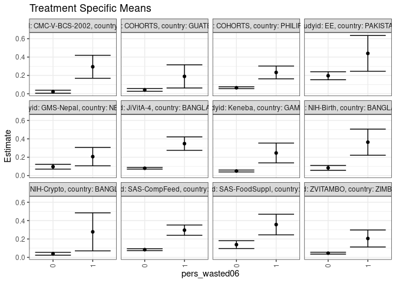

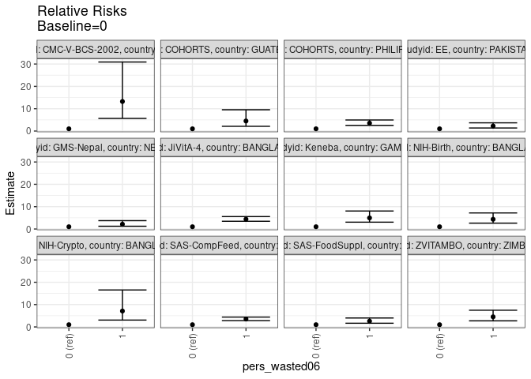

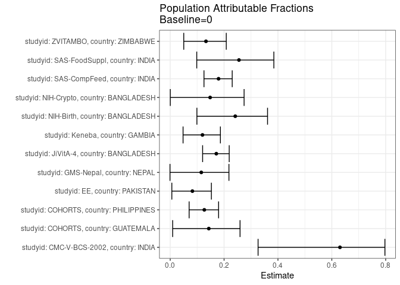

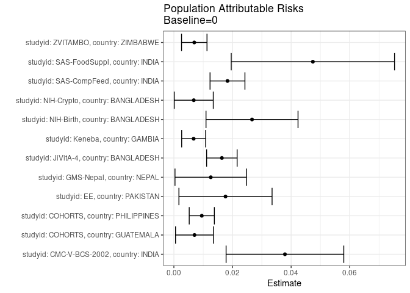

## Results Table

### Parameter: TSM

| studyid | country | intervention_level | baseline_level | estimate | ci_lower | ci_upper |
| --- | --- | --- | --- | --- | --- | --- |
| CMC-V-BCS-2002 | INDIA | 0 | NA | 0.0222222 | 0.0059217 | 0.0385227 |
| CMC-V-BCS-2002 | INDIA | 1 | NA | 0.2941176 | 0.1688947 | 0.4193406 |
| COHORTS | GUATEMALA | 0 | NA | 0.0420624 | 0.0275610 | 0.0565638 |
| COHORTS | GUATEMALA | 1 | NA | 0.1891892 | 0.0629088 | 0.3154696 |
| COHORTS | PHILIPPINES | 0 | NA | 0.0656716 | 0.0556439 | 0.0756994 |
| COHORTS | PHILIPPINES | 1 | NA | 0.2323944 | 0.1629122 | 0.3018765 |
| EE | PAKISTAN | 0 | NA | 0.1962617 | 0.1527507 | 0.2397727 |
| EE | PAKISTAN | 1 | NA | 0.4400000 | 0.2451381 | 0.6348619 |
| GMS-Nepal | NEPAL | 0 | NA | 0.0965092 | 0.0702595 | 0.1227590 |
| GMS-Nepal | NEPAL | 1 | NA | 0.2063492 | 0.1063287 | 0.3063697 |
| JiVitA-4 | BANGLADESH | 0 | NA | 0.0792755 | 0.0701812 | 0.0883698 |
| JiVitA-4 | BANGLADESH | 1 | NA | 0.3478261 | 0.2745684 | 0.4210837 |
| Keneba | GAMBIA | 0 | NA | 0.0495916 | 0.0393109 | 0.0598723 |
| Keneba | GAMBIA | 1 | NA | 0.2459016 | 0.1378080 | 0.3539953 |
| NIH-Birth | BANGLADESH | 0 | NA | 0.0837321 | 0.0571501 | 0.1103141 |
| NIH-Birth | BANGLADESH | 1 | NA | 0.3636364 | 0.2213450 | 0.5059277 |
| NIH-Crypto | BANGLADESH | 0 | NA | 0.0389610 | 0.0236683 | 0.0542538 |
| NIH-Crypto | BANGLADESH | 1 | NA | 0.2777778 | 0.0706975 | 0.4848581 |
| SAS-CompFeed | INDIA | 0 | NA | 0.0836237 | 0.0731686 | 0.0940788 |
| SAS-CompFeed | INDIA | 1 | NA | 0.2962963 | 0.2402584 | 0.3523342 |
| SAS-FoodSuppl | INDIA | 0 | NA | 0.1383399 | 0.0957308 | 0.1809491 |
| SAS-FoodSuppl | INDIA | 1 | NA | 0.3571429 | 0.2447210 | 0.4695647 |
| ZVITAMBO | ZIMBABWE | 0 | NA | 0.0454263 | 0.0352420 | 0.0556105 |
| ZVITAMBO | ZIMBABWE | 1 | NA | 0.2054795 | 0.1127639 | 0.2981950 |

### Parameter: E(Y)

| studyid | country | intervention_level | baseline_level | estimate | ci_lower | ci_upper |
| --- | --- | --- | --- | --- | --- | --- |
| CMC-V-BCS-2002 | INDIA | NA | NA | 0.0601093 | 0.0357249 | 0.0844936 |
| COHORTS | GUATEMALA | NA | NA | 0.0490956 | 0.0338639 | 0.0643273 |
| COHORTS | PHILIPPINES | NA | NA | 0.0751910 | 0.0648251 | 0.0855569 |
| EE | PAKISTAN | NA | NA | 0.2138728 | 0.1706052 | 0.2571404 |
| GMS-Nepal | NEPAL | NA | NA | 0.1090909 | 0.0830130 | 0.1351688 |
| JiVitA-4 | BANGLADESH | NA | NA | 0.0956483 | 0.0855904 | 0.1057063 |
| Keneba | GAMBIA | NA | NA | 0.0563380 | 0.0456085 | 0.0670675 |
| NIH-Birth | BANGLADESH | NA | NA | 0.1103896 | 0.0817833 | 0.1389959 |
| NIH-Crypto | BANGLADESH | NA | NA | 0.0457413 | 0.0294659 | 0.0620168 |
| SAS-CompFeed | INDIA | NA | NA | 0.1019108 | 0.0902026 | 0.1136190 |
| SAS-FoodSuppl | INDIA | NA | NA | 0.1857585 | 0.1432798 | 0.2282372 |
| ZVITAMBO | ZIMBABWE | NA | NA | 0.0523810 | 0.0417242 | 0.0630377 |

### Parameter: RR

| studyid | country | intervention_level | baseline_level | estimate | ci_lower | ci_upper |
| --- | --- | --- | --- | --- | --- | --- |
| CMC-V-BCS-2002 | INDIA | 0 | 0 | 1.000000 | 1.000000 | 1.000000 |
| CMC-V-BCS-2002 | INDIA | 1 | 0 | 13.235294 | 5.667550 | 30.908064 |
| COHORTS | GUATEMALA | 0 | 0 | 1.000000 | 1.000000 | 1.000000 |
| COHORTS | GUATEMALA | 1 | 0 | 4.497820 | 2.121945 | 9.533891 |
| COHORTS | PHILIPPINES | 0 | 0 | 1.000000 | 1.000000 | 1.000000 |
| COHORTS | PHILIPPINES | 1 | 0 | 3.538732 | 2.529571 | 4.950493 |
| EE | PAKISTAN | 0 | 0 | 1.000000 | 1.000000 | 1.000000 |
| EE | PAKISTAN | 1 | 0 | 2.241905 | 1.366245 | 3.678797 |
| GMS-Nepal | NEPAL | 0 | 0 | 1.000000 | 1.000000 | 1.000000 |
| GMS-Nepal | NEPAL | 1 | 0 | 2.138129 | 1.226443 | 3.727524 |
| JiVitA-4 | BANGLADESH | 0 | 0 | 1.000000 | 1.000000 | 1.000000 |
| JiVitA-4 | BANGLADESH | 1 | 0 | 4.387563 | 3.462483 | 5.559799 |
| Keneba | GAMBIA | 0 | 0 | 1.000000 | 1.000000 | 1.000000 |
| Keneba | GAMBIA | 1 | 0 | 4.958534 | 3.049866 | 8.061685 |
| NIH-Birth | BANGLADESH | 0 | 0 | 1.000000 | 1.000000 | 1.000000 |
| NIH-Birth | BANGLADESH | 1 | 0 | 4.342857 | 2.623861 | 7.188037 |
| NIH-Crypto | BANGLADESH | 0 | 0 | 1.000000 | 1.000000 | 1.000000 |
| NIH-Crypto | BANGLADESH | 1 | 0 | 7.129630 | 3.070223 | 16.556328 |
| SAS-CompFeed | INDIA | 0 | 0 | 1.000000 | 1.000000 | 1.000000 |
| SAS-CompFeed | INDIA | 1 | 0 | 3.543210 | 2.845691 | 4.411700 |
| SAS-FoodSuppl | INDIA | 0 | 0 | 1.000000 | 1.000000 | 1.000000 |
| SAS-FoodSuppl | INDIA | 1 | 0 | 2.581633 | 1.661999 | 4.010128 |
| ZVITAMBO | ZIMBABWE | 0 | 0 | 1.000000 | 1.000000 | 1.000000 |
| ZVITAMBO | ZIMBABWE | 1 | 0 | 4.523363 | 2.733035 | 7.486481 |

### Parameter: PAR

| studyid | country | intervention_level | baseline_level | estimate | ci_lower | ci_upper |
| --- | --- | --- | --- | --- | --- | --- |
| CMC-V-BCS-2002 | INDIA | 0 | NA | 0.0378871 | 0.0178137 | 0.0579604 |
| COHORTS | GUATEMALA | 0 | NA | 0.0070332 | 0.0005665 | 0.0134999 |
| COHORTS | PHILIPPINES | 0 | NA | 0.0095194 | 0.0052323 | 0.0138064 |
| EE | PAKISTAN | 0 | NA | 0.0176112 | 0.0017221 | 0.0335002 |
| GMS-Nepal | NEPAL | 0 | NA | 0.0125817 | 0.0003807 | 0.0247826 |
| JiVitA-4 | BANGLADESH | 0 | NA | 0.0163729 | 0.0111669 | 0.0215789 |
| Keneba | GAMBIA | 0 | NA | 0.0067464 | 0.0026606 | 0.0108322 |
| NIH-Birth | BANGLADESH | 0 | NA | 0.0266576 | 0.0109633 | 0.0423518 |
| NIH-Crypto | BANGLADESH | 0 | NA | 0.0067803 | 0.0001243 | 0.0134362 |
| SAS-CompFeed | INDIA | 0 | NA | 0.0182871 | 0.0123348 | 0.0242395 |
| SAS-FoodSuppl | INDIA | 0 | NA | 0.0474186 | 0.0195650 | 0.0752722 |
| ZVITAMBO | ZIMBABWE | 0 | NA | 0.0069547 | 0.0026116 | 0.0112978 |

### Parameter: PAF

| studyid | country | intervention_level | baseline_level | estimate | ci_lower | ci_upper |
| --- | --- | --- | --- | --- | --- | --- |
| CMC-V-BCS-2002 | INDIA | 0 | NA | 0.6303030 | 0.3262436 | 0.7971435 |
| COHORTS | GUATEMALA | 0 | NA | 0.1432550 | 0.0090294 | 0.2593000 |
| COHORTS | PHILIPPINES | 0 | NA | 0.1266023 | 0.0701788 | 0.1796018 |
| EE | PAKISTAN | 0 | NA | 0.0823440 | 0.0059818 | 0.1528399 |
| GMS-Nepal | NEPAL | 0 | NA | 0.1153320 | -0.0008347 | 0.2180152 |
| JiVitA-4 | BANGLADESH | 0 | NA | 0.1711778 | 0.1203441 | 0.2190739 |
| Keneba | GAMBIA | 0 | NA | 0.1197491 | 0.0477138 | 0.1863354 |
| NIH-Birth | BANGLADESH | 0 | NA | 0.2414861 | 0.0990716 | 0.3613883 |
| NIH-Crypto | BANGLADESH | 0 | NA | 0.1482311 | 0.0002406 | 0.2743151 |
| SAS-CompFeed | INDIA | 0 | NA | 0.1794425 | 0.1253465 | 0.2301927 |
| SAS-FoodSuppl | INDIA | 0 | NA | 0.2552701 | 0.0985319 | 0.3847562 |
| ZVITAMBO | ZIMBABWE | 0 | NA | 0.1327714 | 0.0502420 | 0.2081294 |